# PCA

Harsimran Ghai

2026-02-20

# Repository link

https://github.com/harsimranghai91-eng/Principal-Component-Analysis-CHEP-898.git

# Installing the libraries

```r
install.packages("forestmodel",repos = "https://cloud.r-project.org")
```

# loading the libraries and importing the data

```r
library(tidyverse)
library(tidymodels)
```

```r
library(reportRmd)
library(sjPlot)
library(plotly)
library(psych)
library(parallel)
library(finalfit)
library(gtsummary)
library(mlbench)
library(vip)
library(rsample)
library(tune)
library(recipes)
library(yardstick)
library(parsnip)
library(glmnet)
library(themis)
library(corrr)
library(performance)
library(utils)
library(see)
library(forestmodel)
data<-read.csv("can_path_data.csv")
```

# Taking a look into the data

```r
glimpse(data)
```

```
## Rows: 41,187
## Columns: 440
## $ ID                                  <chr> "SYN_58621", "SYN_58622", "SYN_586…
## $ ADM_STUDY_ID                        <int> 5, 5, 5, 5, 5, 5, 5, 5, 5, 5, 5, 5…
## $ SDC_GENDER                          <int> 2, 2, 2, 2, 2, 2, 2, 2, 2, 2, 1, 2…
## $ SDC_AGE_CALC                        <int> 47, 57, 62, 58, 64, 40, 36, 63, 58…
## $ SDC_MARITAL_STATUS                  <int> 1, 1, 1, 1, 1, 1, 1, 3, 1, 3, 1, 1…
## $ SDC_EDU_LEVEL                       <int> 4, 4, 4, 3, 6, 4, 6, 7, 7, 6, 3, 2…
## $ SDC_EDU_LEVEL_AGE                   <int> 20, 22, 18, 17, 40, 20, 22, 27, 38…
## $ SDC_INCOME                          <int> 6, 6, 4, 3, NA, 4, 5, 3, 3, 5, 8, …
## $ SDC_INCOME_IND_NB                   <int> 3, NA, 2, 2, 2, 4, 4, 1, 2, 2, 5, …
## $ SDC_HOUSEHOLD_ADULTS_NB             <int> 2, 2, 2, 2, 2, 2, 2, 2, 2, 1, 2, 2…
## $ SDC_HOUSEHOLD_CHILDREN_NB           <int> 1, NA, 0, 0, 0, 2, 2, 0, 0, 0, 3, …
## $ HS_GEN_HEALTH                       <int> 3, 4, 3, 4, 3, 5, 5, 3, 3, 4, 4, 4…
## $ HS_ROUTINE_VISIT_EVER               <int> 1, 1, 1, 1, 1, 1, 1, 1, 1, 1, 1, 1…
```

[output cut: 427 more lines]

There are total of 440 variables, with total sample size of 41,187.

# Checking duplicated data

```r
duplicated(data)
```

[output not shown]

[output cut: 3418 more lines]

No duplicated data was found in any of the variables list in this dataset.

# Checking the missing values in the dataset

```r
colSums(is.na(data))
```

```
##                                  ID                        ADM_STUDY_ID
##                                   0                                   0
##                          SDC_GENDER                        SDC_AGE_CALC
##                                   0                                   0
##                  SDC_MARITAL_STATUS                       SDC_EDU_LEVEL
##                                 879                                 875
##                   SDC_EDU_LEVEL_AGE                          SDC_INCOME
##                                2817                                5934
##                   SDC_INCOME_IND_NB             SDC_HOUSEHOLD_ADULTS_NB
##                                3754                                2679
##           SDC_HOUSEHOLD_CHILDREN_NB                       HS_GEN_HEALTH
##                                2896                                 672
##               HS_ROUTINE_VISIT_EVER               HS_ROUTINE_VISIT_LAST
##                                1568                                1565
##                HS_DENTAL_VISIT_EVER                HS_DENTAL_VISIT_LAST
##                                1397                                1373
##                        HS_FOBT_EVER                        HS_FOBT_LAST
##                                3165                                3075
##                         HS_COL_EVER                         HS_COL_LAST
##                                6869                                6979
##                         HS_SIG_EVER                         HS_SIG_LAST
##                                7767                                7494
##                     HS_SIG_COL_EVER                     HS_SIG_COL_LAST
##                                1559                                2538
##                       HS_POLYP_EVER                         HS_PSA_EVER
##                                5633                                2486
##                         HS_PSA_LAST                MH_CHILDREN_FATHERED
##                                2439                                 694
##                 WH_MENSTRUATION_AGE              WH_CONTRACEPTIVES_EVER
##                               17026                                 528
##               WH_CONTRACEPTIVES_AGE          WH_CONTRACEPTIVES_DURATION
##                                1487                                4891
##                        WH_GRAVIDITY                   WH_PREG_FIRST_AGE
##                                 744                                 563
##                         WH_PREG_CUR                      WH_PREG_CUR_WK
##                                4188                                4879
##                    WH_PREG_LAST_AGE           WH_BREASTFEEDING_DURATION
##                                 906                                3655
##                         WH_HFT_EVER                   WH_MENOPAUSE_EVER
##                                 921                                 839
```

[output cut: 385 more lines]

```
##                                 526                                 526
##                         WTHNRC15_07                         WTHNRC15_08
##                                 526                                 526
##                         WTHNRC15_09                         WTHNRC15_10
##                                 526                                 526
##                         WTHNRC15_11                         WTHNRC15_12
##                                 526                                 526
##                         WTHNRC15_13                         WTHNRC15_14
##                                 526                                 526
##                         WTHNRC15_15                         WTHNRC15_16
##                                 526                                 526
##                         WTHNRC15_17                         WTHNRC15_18
##                                 526                                 526
##                         WTHNRC15_19                         LGTNLT12_01
##                                 526                                 650
```

From eyeballing the results, it is apparent that all variables except few have missing values, which can be troublesome, as PCA being an unsupervised machine learning method is sensitive to missing values. Therefore, moving forward data will be clean and all the missing values will be drop to do a complete case analysis.

# Checking the structure of the dataset

```r
str(data)
```

```
## 'data.frame':    41187 obs. of  440 variables:
##  $ ID                                 : chr  "SYN_58621" "SYN_58622" "SYN_58623" "SYN_58624" ...
##  $ ADM_STUDY_ID                       : int  5 5 5 5 5 5 5 5 5 5 ...
##  $ SDC_GENDER                         : int  2 2 2 2 2 2 2 2 2 2 ...
##  $ SDC_AGE_CALC                       : int  47 57 62 58 64 40 36 63 58 60 ...
##  $ SDC_MARITAL_STATUS                 : int  1 1 1 1 1 1 1 3 1 3 ...
##  $ SDC_EDU_LEVEL                      : int  4 4 4 3 6 4 6 7 7 6 ...
##  $ SDC_EDU_LEVEL_AGE                  : int  20 22 18 17 40 20 22 27 38 NA ...
##  $ SDC_INCOME                         : int  6 6 4 3 NA 4 5 3 3 5 ...
##  $ SDC_INCOME_IND_NB                  : int  3 NA 2 2 2 4 4 1 2 2 ...
##  $ SDC_HOUSEHOLD_ADULTS_NB            : int  2 2 2 2 2 2 2 2 2 1 ...
##  $ SDC_HOUSEHOLD_CHILDREN_NB          : int  1 NA 0 0 0 2 2 0 0 0 ...
##  $ HS_GEN_HEALTH                      : int  3 4 3 4 3 5 5 3 3 4 ...
##  $ HS_ROUTINE_VISIT_EVER              : int  1 1 1 1 1 1 1 1 1 1 ...
##  $ HS_ROUTINE_VISIT_LAST              : int  2 3 2 3 2 3 3 1 3 5 ...
```

[output cut: 86 more lines]

# Extracting the variables for PCA and PCA regression

```r
data2 <- data|>select(ID,
                       PM_BMI_SR,
                       PA_TOTAL_SHORT,
                       PA_TOTAL_SIT_TIME,
                       PA_TOTAL_WALK_SHORT,
                       PA_TOTAL_MOD_SHORT,
                       PA_TOTAL_SHORT,
                       PA_SIT_TIME_WKDAY,
                       PM_STAND_HEIGHT_SR_AVG,
                       PM_WEIGHT_SR_AVG,
                       PM_WAIST_SR_AVG,
                       PM_WAIST_HIP_RATIO_SR,
                       PM_HIP_SR_AVG,
                       NUT_VEG_QTY,
                       NUT_FRUITS_QTY,
                       NUT_JUICE_QTY,
                       SDC_GENDER,
                       SDC_INCOME,
                       SMK_CIG_STATUS,
                       DIS_ARTHRITIS_AGE,
                       PA_WALK_TIME,
                       PA_SIT_AVG_TIME_DAY)

#converting variables into factors
data2$SDC_GENDER <- as.factor(data2$SDC_GENDER)
data2$SDC_INCOME <- as.factor(data2$SDC_INCOME)
data2$SMK_CIG_STATUS <- as.factor(data2$SMK_CIG_STATUS)
```

Given PCA can only work for continuous variables, we will be extracting the continuous variables for PCA, however given that regression can handle categorical variables, we will also be extracting some of categorical variables to do the later analysis.

# Summary of the continuous variables

```r
rm_covsum(data=data2,
covs=c('PM_BMI_SR',
       'PA_TOTAL_SHORT',
                       'PA_TOTAL_SIT_TIME',
                       'PA_TOTAL_WALK_SHORT',
                       'PA_TOTAL_MOD_SHORT',
                       'PA_TOTAL_SHORT',
                       'PA_SIT_TIME_WKDAY',
                       'PM_STAND_HEIGHT_SR_AVG',
                       'PM_WEIGHT_SR_AVG',
                       'PM_WAIST_SR_AVG',
                       'PM_WAIST_HIP_RATIO_SR',
                       'PM_HIP_SR_AVG',
                       'NUT_VEG_QTY',
                       'NUT_FRUITS_QTY',
                       'NUT_JUICE_QTY',
                       'DIS_ARTHRITIS_AGE',
                        'PA_WALK_TIME',
                       'PA_SIT_AVG_TIME_DAY'))
```

|  | n=41187 |
| --- | --- |
| PM BMI SR |  |
| Mean (sd) | 27.5 (6.2) |
| Median (Min,Max) | 26.6 (8.9, 69.4) |
| Missing | 11976 |
| PA TOTAL SHORT |  |
| Mean (sd) | 2574.1 (2656.2) |
| Median (Min,Max) | 1782 (0, 19278) |
| Missing | 6763 |
| PA TOTAL SIT TIME |  |
| Mean (sd) | 2660.6 (1204.8) |
| Median (Min,Max) | 2520 (0, 6720) |
| Missing | 11272 |
| PA TOTAL WALK SHORT |  |
| Mean (sd) | 1030.5 (1126.3) |
| Median (Min,Max) | 603.9 (0.0, 4158.0) |
| Missing | 10788 |
| PA TOTAL MOD SHORT |  |
| Mean (sd) | 724.3 (1107.3) |
| Median (Min,Max) | 240 (0, 5040) |
| Missing | 9315 |
| PA TOTAL SHORT |  |
| Mean (sd) | 2574.1 (2656.2) |
| Median (Min,Max) | 1782 (0, 19278) |
| Missing | 6763 |
| PA SIT TIME WKDAY |  |
| Mean (sd) | 399.2 (193.4) |
| Median (Min,Max) | 360 (0, 960) |
| Missing | 10141 |
| PM STAND HEIGHT SR AVG |  |
| Mean (sd) | 165.9 (8.4) |
| Median (Min,Max) | 165.1 (121.9, 210.8) |
| Missing | 9801 |
| PM WEIGHT SR AVG |  |
| Mean (sd) | 76.8 (18.4) |
| Median (Min,Max) | 74.4 (27.2, 191.0) |
| Missing | 11707 |
| PM WAIST SR AVG |  |
| Mean (sd) | 92.6 (14.2) |
| Median (Min,Max) | 91.4 (35.9, 168.3) |
| Missing | 16400 |
| PM WAIST HIP RATIO SR |  |
| Mean (sd) | 0.9 (0.1) |
| Median (Min,Max) | 0.9 (0.3, 2.4) |
| Missing | 17734 |
| PM HIP SR AVG |  |
| Mean (sd) | 101.7 (12.6) |
| Median (Min,Max) | 100.3 (33.7, 175.0) |
| Missing | 17349 |
| NUT VEG QTY |  |
| Mean (sd) | 2.7 (1.7) |
| Median (Min,Max) | 2 (0, 35) |
| Missing | 2549 |
| NUT FRUITS QTY |  |
| Mean (sd) | 2.1 (1.4) |
| Median (Min,Max) | 2 (0, 25) |
| Missing | 2426 |
| NUT JUICE QTY |  |
| Mean (sd) | 0.8 (1.1) |
| Median (Min,Max) | 1 (0, 44) |
| Missing | 3583 |
| DIS ARTHRITIS AGE |  |
| Mean (sd) | 3.7 (22.1) |
| Median (Min,Max) | -7 (-7, 73) |
| Missing | 4101 |
| PA WALK TIME |  |
| Mean (sd) | 73.5 (105.1) |
| Median (Min,Max) | 45 (0, 930) |
| Missing | 9417 |
| PA SIT AVG TIME DAY |  |
| Mean (sd) | 391.1 (366.9) |
| Median (Min,Max) | 360 (0, 9999) |
| Missing | 11257 |

# Data Cleaning

```r
#Changing the variables
data3 <- data2%>%mutate(DIS_ARTHRITIS_AGE = if_else(DIS_ARTHRITIS_AGE < 0, NA_real_, DIS_ARTHRITIS_AGE))

#changing the extreme values to 360
data3 <- data2%>%mutate(PA_SIT_AVG_TIME_DAY=case_when(
            PA_SIT_AVG_TIME_DAY > 360 ~ 360,
            TRUE ~ PA_SIT_AVG_TIME_DAY))

#removing the missing variables
data_final <- drop_na(data3)
```

# Summary of final and clean dataset

```r
glimpse(data_final)
```

```
## Rows: 11,840
## Columns: 21
## $ ID                     <chr> "SYN_58628", "SYN_586211", "SYN_586217", "SYN_5…
## $ PM_BMI_SR              <dbl> 32.77998, 26.60839, 32.18397, 39.50651, 27.9881…
## $ PA_TOTAL_SHORT         <dbl> 297.0, 3120.0, 5332.5, 66.0, 4638.0, 720.0, 283…
## $ PA_TOTAL_SIT_TIME      <int> 3300, 2700, 3660, 4200, 2580, 3120, 2460, 3360,…
## $ PA_TOTAL_WALK_SHORT    <dbl> 297.0, 247.5, 742.5, 66.0, 1650.0, 0.0, 990.0, …
## $ PA_TOTAL_MOD_SHORT     <int> 0, 1680, 360, 0, 960, 160, 240, 0, 0, 720, 0, 0…
## $ PA_SIT_TIME_WKDAY      <int> 900, 420, 840, 900, 300, 240, 360, 270, 600, 18…
## $ PM_STAND_HEIGHT_SR_AVG <dbl> 162.56, 185.42, 172.72, 161.29, 149.86, 162.56,…
## $ PM_WEIGHT_SR_AVG       <dbl> 56.47225, 83.91459, 70.76041, 115.21246, 68.152…
## $ PM_WAIST_SR_AVG        <dbl> 106.0000, 91.4400, 92.7100, 113.0300, 90.8050, …
## $ PM_WAIST_HIP_RATIO_SR  <dbl> 0.8400000, 0.9000000, 0.8114754, 0.7818182, 0.8…
## $ PM_HIP_SR_AVG          <dbl> 127.31750, 101.60000, 116.20500, 139.70000, 107…
## $ NUT_VEG_QTY            <int> 5, 1, 4, 1, 3, 3, 1, 2, 2, 4, 2, 2, 3, 2, 4, 2,…
## $ NUT_FRUITS_QTY         <int> 2, 1, 3, 2, 2, 2, 2, 2, 1, 3, 1, 1, 3, 2, 1, 3,…
## $ NUT_JUICE_QTY          <int> 0, 1, 0, 0, 0, 1, 0, 0, 0, 1, 0, 1, 2, 0, 0, 2,…
## $ SDC_GENDER             <fct> 2, 1, 2, 2, 2, 2, 2, 1, 2, 1, 1, 2, 1, 1, 2, 2,…
## $ SDC_INCOME             <fct> 3, 8, 4, 4, 5, 5, 3, 5, 4, 5, 7, 4, 7, 5, 4, 5,…
## $ SMK_CIG_STATUS         <fct> 0, 0, 0, 0, 0, 0, 0, 1, 1, 1, 0, 0, 1, 0, 3, 0,…
## $ DIS_ARTHRITIS_AGE      <int> -7, -7, -7, -7, -7, -7, -7, -7, -7, -7, -7, -7,…
## $ PA_WALK_TIME           <int> 45, 15, 45, 20, 110, 0, 60, 90, 0, 330, 62, 30,…
## $ PA_SIT_AVG_TIME_DAY    <dbl> 360.0000, 360.0000, 360.0000, 360.0000, 360.000…
```

This dataset contains 21 variables and a total of 11,840 observations.Therefore, a large chunk of data was removed due to their missingnesss.

# Correlation Analysis

```
## Non-numeric variables removed from input: `ID`, `SDC_GENDER`, `SDC_INCOME`, and `SMK_CIG_STATUS`
## Correlation computed with
## • Method: 'pearson'
## • Missing treated using: 'pairwise.complete.obs'
```

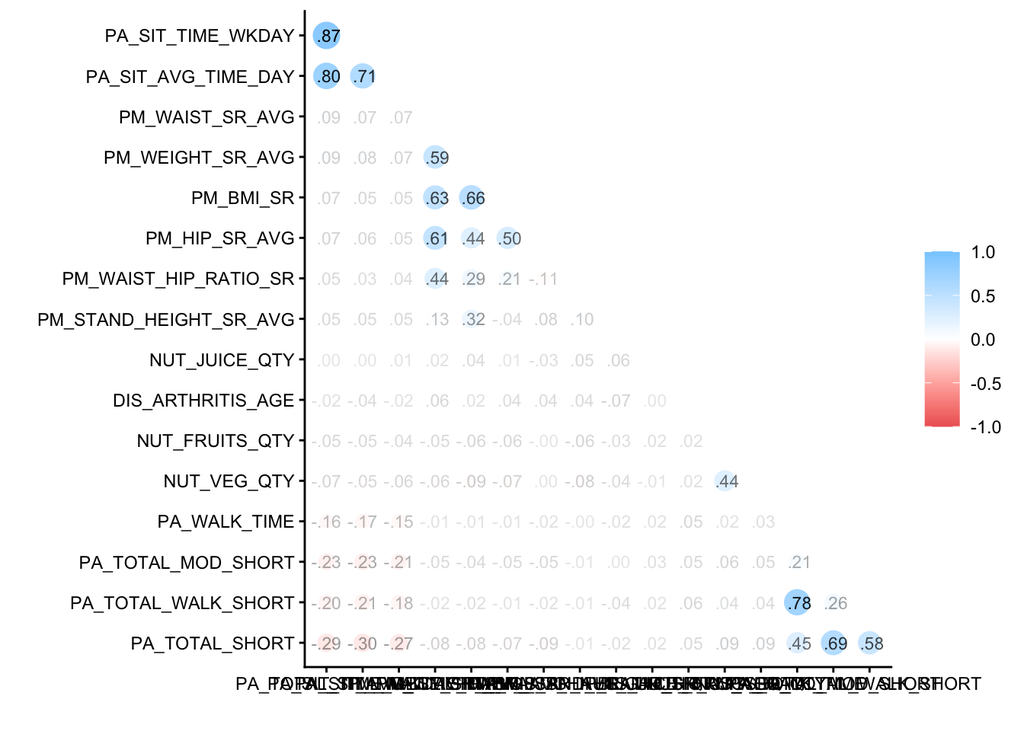

```r
data_final %>%
  correlate() %>%
  rearrange() %>%
  shave()  %>%
  rplot(print_cor=TRUE)
```

Some variables according to the correlation analysis has moderate to strong positive correlation, while other has very weak correlation. For the sake of practice, I am continuing with the PCA, however given the lack of correlation between some of the variables, ideally we should only include variables that are related as we want to use the relationship among the variables to reduce the dimension of the dataset.

# Conducting the PCA

## Creating the recipe

```r
pca_recipe <- recipe(~., data = data_final) %>%
  update_role(ID,
              SDC_GENDER,
              SDC_INCOME,
              SMK_CIG_STATUS, new_role = "id") %>%
  step_scale(all_predictors()) %>%
  step_center(all_predictors()) %>%
  step_pca(all_predictors(), id = "pca_id")

pca_recipe
```

```
## ── Recipe ──────────────────────────────────────────────────────────────────────
```

```
## ── Inputs
```

```
## Number of variables by role
```

```
## predictor: 17
## id:         4
```

```
## ── Operations
```

```
## • Scaling for: all_predictors()
```

```
## • Centering for: all_predictors()
```

```
## • PCA extraction with: all_predictors()
```

## Prepare

```r
pca_prepared <- prep(pca_recipe)

pca_prepared
```

```
## ── Recipe ──────────────────────────────────────────────────────────────────────
```

```
## ── Inputs
```

```
## Number of variables by role
```

```
## predictor: 17
## id:         4
```

```
## ── Training information
```

```
## Training data contained 11840 data points and no incomplete rows.
```

```
## ── Operations
```

```
## • Scaling for: PM_BMI_SR, PA_TOTAL_SHORT, PA_TOTAL_SIT_TIME, ... | Trained
```

```
## • Centering for: PM_BMI_SR, PA_TOTAL_SHORT, PA_TOTAL_SIT_TIME, ... | Trained
```

```
## • PCA extraction with: PM_BMI_SR PA_TOTAL_SHORT, ... | Trained
```

## Baking

```r
pca_baked <- bake(pca_prepared, data_final)
pca_baked
```

```
## # A tibble: 11,840 × 9
##    ID         SDC_GENDER SDC_INCOME SMK_CIG_STATUS    PC1     PC2     PC3    PC4
##    <chr>      <fct>      <fct>      <fct>           <dbl>   <dbl>   <dbl>  <dbl>
##  1 SYN_58628  2          3          0              -2.59  -0.288  -0.463  -1.86
##  2 SYN_586211 1          8          0              -0.824  0.0907  0.0480  1.37
##  3 SYN_586217 2          4          0              -1.55  -0.212  -1.41   -1.57
##  4 SYN_586219 2          4          0              -4.54   2.00   -0.257  -0.707
##  5 SYN_586221 2          5          0               0.777 -0.0895 -0.633  -0.378
##  6 SYN_586230 2          5          0              -1.03  -0.509   0.980   0.129
##  7 SYN_586243 2          3          0               0.101 -1.04    0.132   0.582
##  8 SYN_586246 1          5          1              -0.902  1.14   -0.404   0.685
##  9 SYN_586250 2          4          1              -3.79   1.79    0.274   0.479
## 10 SYN_586253 1          5          1               1.83   2.85   -2.03   -0.282
## # ℹ 11,830 more rows
## # ℹ 1 more variable: PC5 <dbl>
```

## Components loadings and Graphs

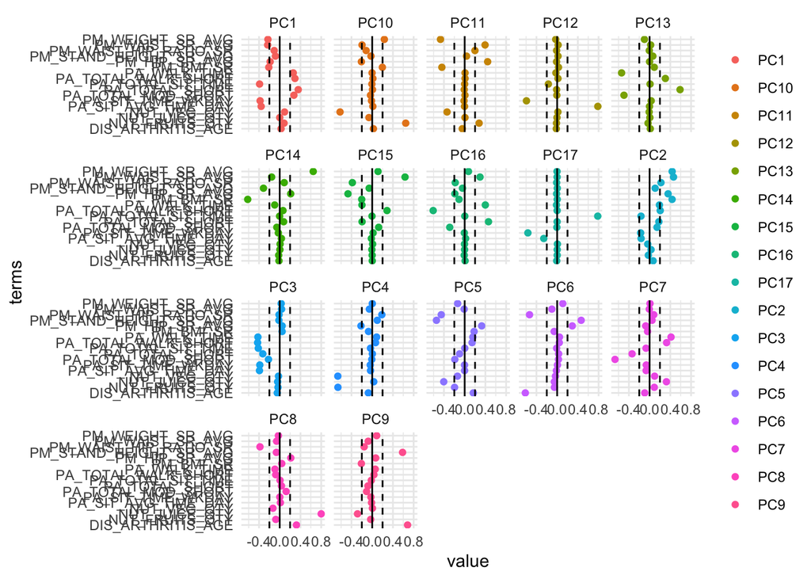

```r
pca_variables <- tidy(pca_prepared, id = "pca_id", type = "coef")

ggplot(pca_variables) +
  geom_point(aes(x = value, y = terms, color = component))+
  labs(color = NULL) +
  geom_vline(xintercept=0) +
  geom_vline(xintercept=-0.2, linetype = 'dashed') +
  geom_vline(xintercept=0.2, linetype = 'dashed') +
  facet_wrap(~ component) +
  theme_minimal()
```

Interpretation: The interpretation of some of the components are as follows based on the loading value of each variables on the principal component. We used the criteria of loading greater than 0.2 and less than -0.2 to interpret the factors. The first factors based on the loading can be interpreted as physical activity, the second variable being anthropometric, the third variable can be interpreted as sitting and walk time and fourth component is fruits and vegetable quantity. All other components are hard to interpret.

## Variance explained by principal components and selecting the components

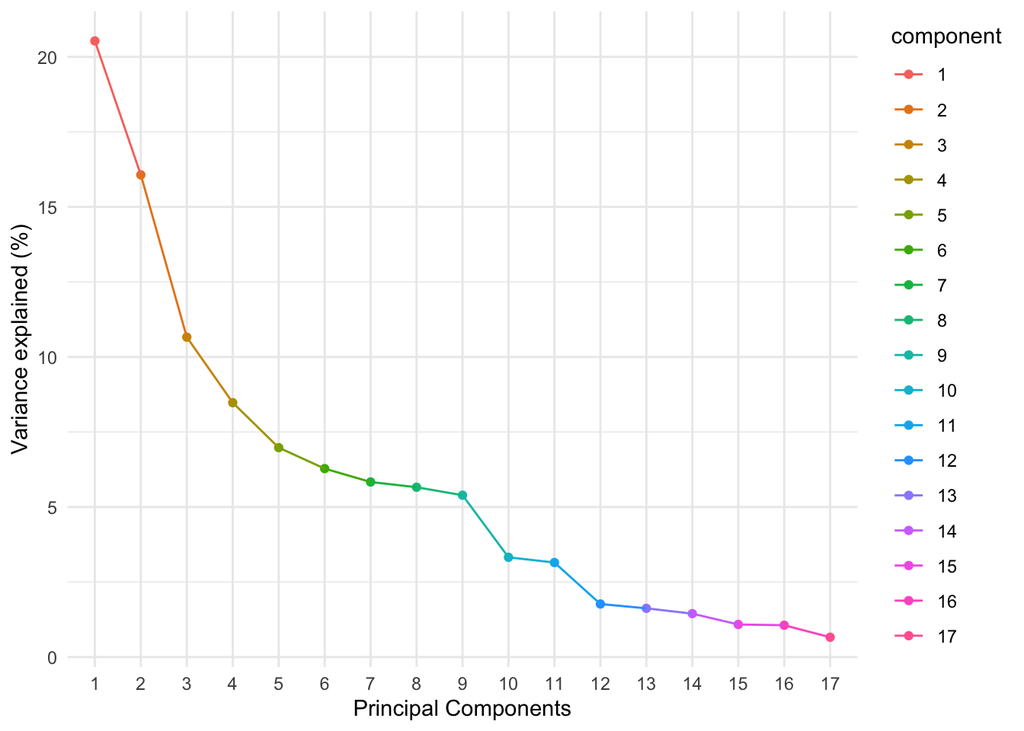

```r
pca_variances <- tidy(pca_prepared, id = "pca_id", type = "variance")

pca_variance <- pca_variances |> filter(terms == "percent variance")
pca_variance$component <- as.factor(pca_variance$component)
pca_variance$comp <- as.numeric(pca_variance$component)

ggplot(pca_variance, aes(x = component, y = value, group = 1, color = component)) +
  geom_point() +
  geom_line() +
  labs(x = "Principal Components", y = "Variance explained (%)") +
  theme_minimal()
```

## Cummulative Variance

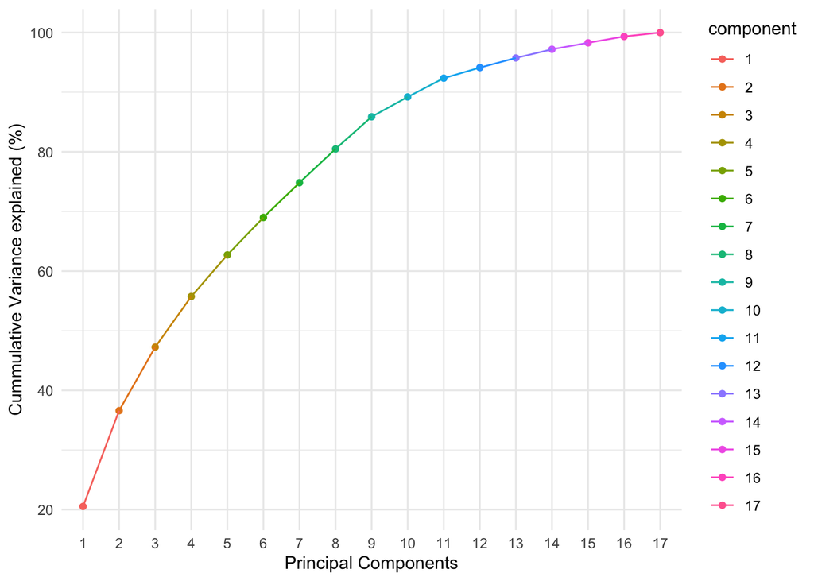

```r
pca_cummul_variance <- pca_variances |> filter(terms == "cumulative percent variance")
pca_cummul_variance$component <- as.factor(pca_cummul_variance$component)
pca_cummul_variance$comp <- as.numeric(pca_cummul_variance$component)

ggplot(pca_cummul_variance, aes(x = component, y = value, group = 1, color = component)) +
  geom_point() +
  geom_line() +
  labs(x = "Principal Components", y = "Cummulative Variance explained (%)") +
  theme_minimal()
```

## Relationship between the components

```
## Correlation computed with
## • Method: 'pearson'
## • Missing treated using: 'pairwise.complete.obs'
```

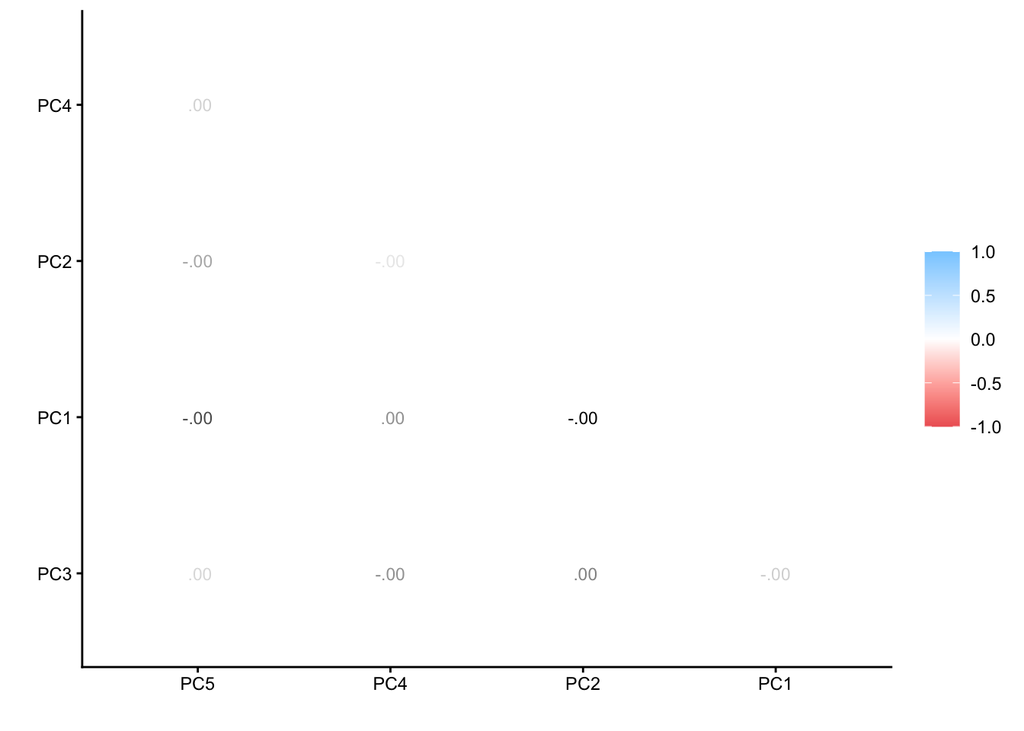

```r
#excluding the categorical variables
pca_corr <- pca_baked |>
  select(-c(ID, SMK_CIG_STATUS, SDC_INCOME, SDC_GENDER))

#creating a correlation matrix for the components
pca_corr %>%
  correlate() %>%
  rearrange() %>%
  shave()  %>%
  rplot(print_cor=TRUE)
```

As expected, none of the components are correlated with each other, showing that the assumption of independence of component is valid.

# Regression analysis with PCA Components

The initial regression analysis will be done without choosing the component. After that, regression would be conducted with only three components (tuned model) and then the model will be compared based on their performance on the testing dataset. Models will also be compared based on residuals analysis.

## Setting the seed and Splitting the data for training and testing the model

```r
set.seed(10)

data_split <- initial_split(data_final, prop = 0.70)

train_data <- training(data_split)
summary(train_data$PM_BMI_SR)
```

```
##    Min. 1st Qu.  Median    Mean 3rd Qu.    Max.
##   10.04   23.43   26.50   27.44   30.21   69.40
```

```r
test_data  <- testing(data_split)
summary(test_data$PM_BMI_SR)
```

```
##    Min. 1st Qu.  Median    Mean 3rd Qu.    Max.
##   10.50   23.55   26.55   27.49   30.28   61.32
```

As evident from the summary, five point summary and mean are close to each other for the dependent variable in training and testinf dataset.

## Building the model

```r
linear_model <- linear_reg() %>%
        set_engine("glm") %>%
        set_mode("regression")
```

## Recipe

```r
pca_reg_recipe <- recipe(PM_BMI_SR ~., data = train_data) %>%
  update_role(ID, new_role = "id") %>%
  step_scale(all_numeric_predictors()) %>%
  step_center(all_numeric_predictors()) %>%
  step_pca(all_numeric_predictors(),num_comp = 17, id = "pca_id")

pca_reg_recipe
```

```
## ── Recipe ──────────────────────────────────────────────────────────────────────
```

```
## ── Inputs
```

```
## Number of variables by role
```

```
## outcome:    1
## predictor: 19
## id:         1
```

```
## ── Operations
```

```
## • Scaling for: all_numeric_predictors()
```

```
## • Centering for: all_numeric_predictors()
```

```
## • PCA extraction with: all_numeric_predictors()
```

## Workflow

```r
bmi_workflow <-
        workflow() %>%
        add_model(linear_model) %>%
        add_recipe(pca_reg_recipe)

bmi_workflow
```

```
## ══ Workflow ════════════════════════════════════════════════════════════════════
## Preprocessor: Recipe
## Model: linear_reg()
##
## ── Preprocessor ────────────────────────────────────────────────────────────────
## 3 Recipe Steps
##
## • step_scale()
## • step_center()
## • step_pca()
##
## ── Model ───────────────────────────────────────────────────────────────────────
## Linear Regression Model Specification (regression)
##
## Computational engine: glm
```